# ReallySimpleExample

Note that the running notebook is now reordered from newest to oldest. All of the dated headings represent a new round of work. Also, make sure to click "toggle input" to turn the code cells off.

```python
from adsy.display import extended_styles
```

```python
extended_styles()
```

Toggle Input

# Changing the Utility Functions 6/30

After running through all of the results below, we found a weird result. Simply put, when the cost to the defender of an attacker penetrating was relatively high, the defender's best response would *increase* in the amount of attack. The reason for this is that the defender's utility does not depend on the level of attack. Therefore, the defender will raise the threshold to entice the attacker to attack more so that he will be easier to detect. This is counterintuitive because the defender, in the real world, would suffer more from higher attacks.

Luckily, much of the math is still the same.

### Assumptions

- $f$ is a continuous, twice differentiable function on an interval of the extended real line.
- **Strict** Log Concavity of $f$
- $\displaystyle \liminf_{x \rightarrow \pm \infty}[ln(f(x))''] <0$
- A slightly stronger consition is that $f$ is strictly log concave at infinity.
  - What this means is that $\displaystyle \lim_{x \rightarrow \pm \infty} [ln(f(x))]''$ exists and $<0$ or equivalently, $\displaystyle\lim_{x \rightarrow \pm \infty}\bigg[\frac{f''(x)f(x) - f'(x)^2}{f(d)^2}\bigg]<0$
  - The difference between the two conditions is that the first one does not require the limit to exist. However, I will use this one in the writeup (for now).

Some immediate implications are:

- $f$ is at most single peaked
- If $f$ is defined on the extended real line, it is single peaked

### The Attacker

The attackers expected utility is given by

\begin{equation} EU_a(d,a) = aF(d-a) \end{equation}

The first order condition is given by \begin{equation} EU'_a(d,a)= F(d-a) -af(d-a) = 0 \end{equation}

We want to show:

- The solution a* to the first order condition is a maximum

and investigate

- The slope of the attacker's best response function.

**Claim - A1:** The solution, $a^*$ to $EU'_a(d,a)$ exists for any $d$ in the support of $f$, and is unqiue and $>0$.

**Proof - A1:** The FOC can be rewritten as $\frac{F(d-a)}{f(d-a)} = a$. At $a=0, \frac{F(d-a)}{f(d-a)}>0 $ which implies $\frac{F(d-a)}{f(d-a)} - a >0$. Furthermore, let $\overline{a} = \frac{F(d)}{f(d)}$ which must be $>0$. By log concavity, $\frac{F(d-a)}{f(d-a)}$ is decreasing in $a$, so for all $a' > \overline{a}$ we have that $\frac{F(d-a')}{f(d-a')} - a' < 0$. By the intermediate value theorem there exists an $a^* \in (0, \overline{a})$ such that $\frac{F(d-a)}{f(d-a)} -a =0$. Furthermore, since $\frac{F(d-a)}{f(d-a)} - a $ is strictly monotone decreasing in $a$, $a^*$ is unique.

**Claim - A2:** The solution, $a^*$ to $EU'_a(d,a)$ is a maximum.

**Proof - A2:** At $a^*$ we have that $\frac{F(d-a^*)}{f(d-a^*)} - a =0$ . For any $\underline{a} < a^*$, we know by log concavity that $\frac{F(d-\underline{a})}{f(d-\underline{a})} > \frac{F(d-a^*)}{f(d-a^*)}$. Therefore we must have that $\frac{F(d-\underline{a})}{f(d-\underline{a})} - \underline{a} >0$. Parallel reasoning shows that for any $\overline{a} > a^*$, $\frac{F(d-\overline{a})}{f(d-\overline{a})}< \frac{F(d-a^*)}{f(d-a^*)}$ and therefore $\frac{F(d-\overline{a})}{f(d-\overline{a})} - \overline{a} <0$. This establishes that for $\underline{a} < a^*$, $EU_a(d,\underline{a})$ is increasing and for any $\overline{a}>a^*$, $EU_a(d,\overline{a})$ is decreasing which is sufficient to establish that $a^*$ is a maximum.

**Claim A-3:** The attacker's best response is increasing in $d$.

### The Defender

The defender's expected utility is given by \begin{equation} EU_d(d,a) = (1-\pi)XF(d) - \pi cF(d-a)a \end{equation}

Note the $a$ term on the second term. This is the addition

The first order condition is

\begin{equation} EU'_d(d,a) = (1-\pi)Xf(d) - \pi cf(d-a)a =0 \end{equation}

and the second order condition is

\begin{equation} EU''_d(d,a) = (1-\pi)Xf'(d) - \pi cf'(d-a)a <0 \end{equation}

We now want to show:

- The solution, $d^*$, to the first order condition is a maximum

and investigate

- The slope of the best response function (i.e. $\frac{dd}{da}$).

**Claim D-1:** $\frac{f(d)}{f(d-a)}$ decreasing in $d$ is sufficient to establish $d^*$ is a maximum.

**Proof D-1:** At $d^*$, it must be that $\frac{\pi c a}{(1-\pi)X} = \frac{f(d^*)}{f(d^*-a)}$. If $\frac{f(d^*)}{f(d^*-a)}$ is decreasing in d, then for any $\underline{d} < d^*$ we have $\frac{\pi a c}{(1-\pi)X} <\frac{f(\underline{d})}{f(\underline{d}-a)}$. This implies that $(1-\pi)Xf(\underline{d}) - \pi cf(\underline{d}-a)a=EU'(\underline{d}) > 0$, which implies $EU_d$ is increasing at any $\underline{d} < d^*$. Parallel reasoning shows that for any $\overline{d} > d^*$ we must have $EU'(\overline{d}) < 0$, which implies $EU_d$ is decreasing at any $\overline{d} > d^*$. This is sufficient for $d^*$ to be a unique, global maximum.

**Claim D-2:** $H(d) = \frac{f(d)}{f(d-a)}$ is decreasing in $d$. (Alternatively put, $H'(d)<0$)

**Proof D-2:** Since log is a monotonic transformation, it sufficies to show that $\hat{H}(d) = ln(H(d)) = ln(f(d)) - ln(f(d-a))$ is decreasing in $d$. Note that $\hat{H}(d) = \int_{d-a}^d\frac{f'(x)}{f(x)}dx$. Applying Leibnitz rule, we see tht $\hat{H}'(d) = \frac{f'(d)}{f(d)} - \frac{f'(d-a)}{f(d-a)}$. However, because $f$ is log concave, $\frac{f'(d)}{f(d)}$ is decreasing in $d$. Therefore, $\hat{H}'(d) <0$.

We now seek to prove the existence of the defender's best response where the support of $f$ is the entire real line

**Claim D-3:** If $\displaystyle \lim_{d \rightarrow \infty} \frac{f'(d)}{f(d)} = -\infty$, then $\displaystyle \lim_{d \rightarrow \infty} \frac{f(d)}{f(d-a)} = 0$.

**Proof D-3:** It suffices to show that $\displaystyle\lim_{d \rightarrow \infty} ln(f(d)) - ln(f(d-a)) = -\infty$. By the mean value theorem, we know that for any $d$ and fixed $a$, $\exists x \in [d, d-a]$ such that $\frac{ln(f(d)) - ln(f(d-a))}{a} = \frac{f'(x)}{f(x)}$. Therfore, if $ \frac{f'(d)}{f(d)}$ goes to $- \infty$, then $ln(f(d)) - ln(f(d-a))$ goes to $- \infty$ as $d$ goes to $\infty$ and therefore $\displaystyle \lim_{d \rightarrow \infty} \frac{f(d)}{f(d-a)} = 0$.

**Claim D-4:** $\displaystyle \lim_{d \rightarrow \infty} \frac{f'(d)}{f(d)} = -\infty$

**Proof D-4:** Since $\frac{f'(d)}{f(d)}$ is monotone decreasing and $f'(d)<0$ so $\displaystyle \lim_{d \rightarrow \infty} \frac{f'(d)}{f(d)}$ is either some negative constant or $-\infty$. However, if $\frac{f'(d)}{f(d)}$ converged to some negative constant, then it must be that $\displaystyle\lim_{x \rightarrow \infty}\bigg[\frac{f''(x)f(x) - f'(x)^2}{f(d)^2}\bigg]=0$. However, this contradicts the assumption of log-concavity at the limit and therefore, it is impossible for $\frac{f'(d)}{f(d)}$ to converge to some negative constant.

**Claim D-5:** $\displaystyle \lim_{d \rightarrow - \infty} \frac{f(d)}{f(d-a)} = \infty$.

**Proof D-5:** This is the same as the above argument but "going the other way."

**Claim D-6:** The solution to the defender's FOC exists.

**Proof D-6:** Because $\displaystyle \lim_{d \rightarrow - \infty} \frac{f(d)}{f(d-a)} = \infty$ and $\displaystyle \lim_{d \rightarrow \infty} \frac{f(d)}{f(d-a)} = 0$, by the intermediate value theorem, there exists a $d^*$ such that $\frac{f(d^*)}{f(d^*-a)}=\frac{\pi c a}{(1-\pi)X}$.

We already know that the attacker's best response is increasing in $d$. Now, let's look at the slope of the defender's best response.

Recall, the defender's best response is given by \begin{equation} \frac{f(d)}{f(d-a)} - Ra = 0 \end{equation}

where $R = \frac{\pi c}{(1-\pi)X}$ is a function of parameters. Let $K(d,a) = \frac{f(d)}{f(d-a)} - Ra $, then the best response for the defender is given by $\frac{dd}{da} = - \frac{K_a}{K_d}$ where:

\begin{equation} K_a = \frac{f(d)f'(d-a) - Rf(d-a)^2}{f(d-a)^2} \end{equation}

and

\begin{equation} K_d = \frac{f(d-a)f'(d) - f(d)f'(d-a)}{f(d-a)^2} \end{equation}

and therefore

\begin{equation} - \frac{K_a}{K_d} = \frac{-f(d)f'(d-a) + Rf(d-a)^2}{f(d-a)f'(d) - f(d)f'(d-a)} \end{equation}

By log concavity, the denominator is negative because $\frac{f'(d)}{f(d)}<\frac{f'(d-a)}{f(d-a)}$

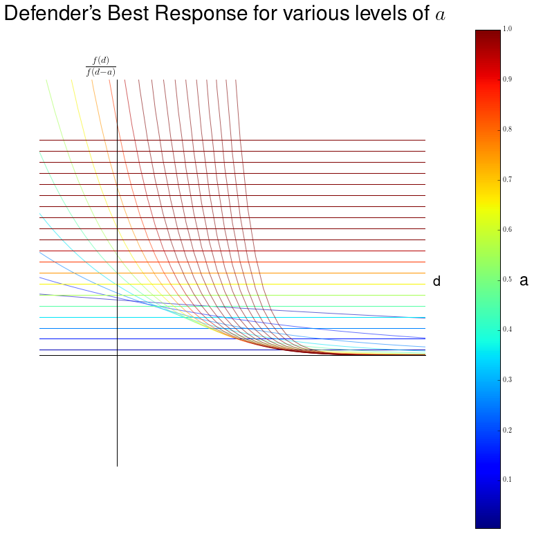

```python
from scipy.stats import norm
import matplotlib as mpl
from matplotlib import pyplot as plt
import numpy as np
%matplotlib inline
from matplotlib import rc
rc('font',**{'family':'sans-serif','sans-serif':['Helvetica']})
rc('text', usetex=True)

from matplotlib import rc
rc('font',**{'family':'sans-serif','sans-serif':['Helvetica']})
## for Palatino and other serif fonts use:
#rc('font',**{'family':'serif','serif':['Palatino']})
rc('text', usetex=True)
c1=1
fig, ax = plt.subplots(figsize=(10,10))
d = np.arange(-5, 5, .1)
for a in np.arange(.1, 4, .2):
    c=plt.cm.jet(a / 2.)
    ax.plot(d, norm.pdf(d)/norm.pdf(d-a), color=c, lw=1, alpha=0.6)
    ax.plot(np.arange(-10,10,1), a*c1*np.ones(len(np.arange(-10, 10,1))), color=c)

ax.spines['left'].set_position('zero')
ax.spines['right'].set_color('none')
ax.spines['bottom'].set_position('zero')
ax.spines['top'].set_color('none')
ax.spines['left']#.set_smart_bounds(True)
ax.spines['bottom']#.set_smart_bounds(True)
ax.xaxis.set_ticks_position('bottom')
ax.yaxis.set_ticks_position('left')
ax.set_xlim(-1,4)
ax.set_ylim(-2, 5)
ax.set_ylabel("d", rotation="horizontal", fontsize=20)
ax.yaxis.set_label_coords(1.03, .46)
ax.set_xlabel("$\\frac{f(d)}{f(d-a)}$", fontsize=20)
ax.xaxis.set_label_coords(.16, 1.06)
ax.xaxis.set_ticks([])
ax.yaxis.set_ticks([])
ax.legend(loc=(1,1))
#ax.plot(np.arange(-10,10,1), 1.5*np.ones(len(np.arange(-10, 10,1))), color="black", linewidth=2.5)
#ax.text(5,1.5, "$\\frac{\\pi c}{(1-\\pi)X}$", ha="left", va="center", fontsize=20)
#ax.plot(np.arange(-10,10,1), .5*np.ones(len(np.arange(-10, 10,1))), color="black", linewidth=2.5)
#ax.text(5,.5, "$\\frac{\\hat{\\pi} \\hat{c}}{(1-\\hat{\\pi})\\hat{X}}$", ha="left", va="center", fontsize=20)
ax2=fig.add_axes([1,0,.05,1])
ax2.set_xticks([])
cmap = mpl.cm.jet
norm = mpl.colors.Normalize(vmin=.005, vmax=1)
cb1 = mpl.colorbar.ColorbarBase(ax2, cmap=cmap,
                                norm=norm,
                                   orientation='vertical')
ax2.set_ylabel("a", rotation="horizontal", fontsize=24)
ax2.yaxis.set_label_coords(2, .51)
fig.suptitle("Defender\'s Best Response for various levels of $a$", fontsize=30, y=1.05)
```

In the above plot, the defender's best response for the various level of attack are the points where lines of the same color cross. We see that there still exists a point where the defender's best response is increasing in $a$.

# Numerical BR functions

Here I am a bit lost so I will try and plot a numerical BR function.

```python
c=1
import scipy.optimize
from scipy.stats import norm
def asolve_outer(d):
    def asolve(a, d=d):
        return norm.cdf(d-a, loc=2)/norm.pdf(d-a, loc=2) - a
    a = scipy.optimize.broyden1(asolve, [1], maxiter=10000)[0]
    return a

def dsolve_outer(a, c=.3):
    def dsolve(d, a=a):
        return norm.pdf(d, loc=2)/norm.pdf(d-a, loc=2) - a*c
    d = scipy.optimize.broyden1(dsolve, [1], maxiter=10000)[0]
    return d
```

```python
dset = np.arange(-15, 15, .1)
aopt = []
for d in dset:
    aopt.append(asolve_outer(d))
aset = np.arange(.1, 13,.1)
dopt=[]
for a in aset:
    dopt.append(dsolve_outer(a))
```

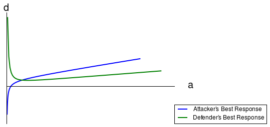

```python
fig, ax = plt.subplots()
ax.set_xlabel("d", fontsize=20)
ax.set_ylabel("a", rotation="horizontal", fontsize=20)
ax.plot(aopt, dset, label="Attacker\'s Best Response", lw=2)
ax.plot(aset, dopt, label="Defender\'s Best Response", lw=2)
ax.xaxis.set_ticks([])
ax.yaxis.set_ticks([])
ax.xaxis.set_ticks_position('bottom')
ax.yaxis.set_ticks_position('left')
ax.spines['left'].set_position('zero')
ax.spines['right'].set_color('none')
ax.spines['bottom'].set_position('zero')
ax.spines['top'].set_color('none')
ax.spines['left']#.set_smart_bounds(True)
ax.spines['bottom']#.set_smart_bounds(True)
ax.yaxis.set_label_coords(1.1, .3)
ax.xaxis.set_label_coords(0, 1.08)
plt.legend(loc=(1,0));
```

This is VERY interesting because it looks like the Nash equilibrium will always be such that the slope of the defender's best response is negative. Let's see what happens when we change the parameters.

```
(-3, 20)
```

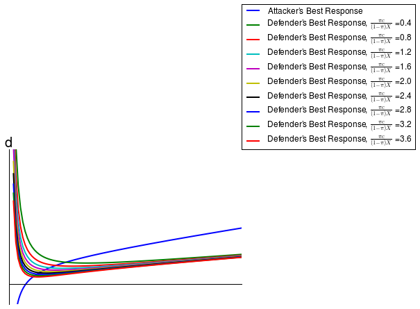

```python
dset = np.arange(-15, 15, .05)
aopt = []
for d in dset:
    aopt.append(asolve_outer(d))
aset = np.arange(.1, 13,.05)
dopt=[]
for a in aset:
    dopt.append(dsolve_outer(a))

fig, ax = plt.subplots()
ax.set_xlabel("d", fontsize=20)
ax.set_ylabel("a", rotation="horizontal", fontsize=20)
ax.plot(aopt, dset, label="Attacker\'s Best Response", lw=2)
#ax.plot(aset, dopt, label="Defender\'s Best Response", lw=2)
ax.xaxis.set_ticks([])
ax.yaxis.set_ticks([])
ax.xaxis.set_ticks_position('bottom')
ax.yaxis.set_ticks_position('left')
ax.spines['left'].set_position('zero')
ax.spines['right'].set_color('none')
ax.spines['bottom'].set_position('zero')
ax.spines['top'].set_color('none')
ax.spines['left']#.set_smart_bounds(True)
ax.spines['bottom']#.set_smart_bounds(True)
ax.yaxis.set_label_coords(1.1, 1.03)
ax.xaxis.set_label_coords(0, 1.08)
plt.legend(loc=(1,0))
for c in np.arange(.4, 4, .4):
    dopt=[]
    for a in aset:
        dopt.append(dsolve_outer(a, c=c))
    ax.plot(aset, dopt, label=r"Defender's Best Response, $\frac{\pi c}{(1-\pi)X}$ =" +str(c), lw=2)
plt.legend(loc=(1,1))
ax.set_xlim(0,5)
ax.set_ylim(-3,20)
```

So far here is what we know when the support of the noise is the entire real line

- the attacker's best response is increasing in d
- The defender's best response will be decreasing and then increasing.
- I need a way to show that these two best responses cross.

Of course, this is only for the normal distribution and might not be in general. However, I am attempting to show that the lines do indeed cross. I am trying to take advantage of the fact that it **looks like** the lines cross before the defender's BR begins to increasin in $a$.

I looked into contraction mappings and I can prove (I think) that the best response functions do not define a contraction mapping and therefore cannot take that approach.

# Fixing Errors and more generalizing 5/24-6/15

### Fixing Errors with functional form

Below I claim that "if $c\pi >X(1-\pi)$, then the defender sets the threshold to 1."

The original math I did was corret, I just drew the incorrect conclusion. Anyway, I will do it below with derivatives

###### Claim : if $c\pi >X(1-\pi)$, then the defender sets the threshold to a.

The expected utility is given by \begin{equation} EU(d)_d =(1-\pi)X(2d-d^2) - \pi c\big[2(d-a) - (d-a)^2\big] \end{equation}

Taking the derivative w.r.t. $d$ we get \begin{equation} EU'(d)_d =(1-\pi)X(1-d) - \pi c(1-d+a) \end{equation}

For any $a>0$, and $d>a$, we have that $(1-d+a)>(1-d)$. Therefore if $\pi c > (1-\pi)X$, the derivative is unambiguously negative and the defender's optimal strategy is to set a threshold to a, which means he sounds the alarm whenever there is a positive probability of an attacker.

## Generalizing the probability distribution

Here I am sketching out sufficient conditions for there to exist a unique interior Nash equilibrium.

### Assumptions:

- $f$ is a continuous, twice differentiable function on an interval of the extended real line.
- **Strict** Log Concavity of $f$
- $\displaystyle \liminf_{x \rightarrow \pm \infty}[ln(f(x))''] <0$
- A slightly stronger consition is that $f$ is strictly log concave at infinity.
  - What this means is that $\displaystyle \lim_{x \rightarrow \pm \infty} [ln(f(x))]''$ exists and $<0$ or equivalently, $\displaystyle\lim_{x \rightarrow \pm \infty}\bigg[\frac{f''(x)f(x) - f'(x)^2}{f(d)^2}\bigg]<0$
  - The difference between the two conditions is that the first one does not require the limit to exist. However, I will use this one in the writeup (for now).

Some immediate implications are:

- $f$ is at most single peaked
- If $f$ is defined on the extended real line, it is single peaked

###### Attacker's best response

Recall the attackers expected utility is given by

\begin{equation} EU_a(d,a) = aF(d-a) \end{equation}

The first order condition is given by \begin{equation} EU'_a(d,a)= F(d-a) -af(d-a) = 0 \end{equation}

We want to show:

- The solution a* to the first order condition is a maximum

and investigate

- The slope of the attacker's best response function.

**Claim:** The solution, $a^*$ to $EU'_a(d,a)$ exists for any $d$ in the support of $f$, and is unqiue and $>0$.

**Proof:** The FOC can be rewritten as $\frac{F(d-a)}{f(d-a)} = a$. At $a=0, \frac{F(d-a)}{f(d-a)}>0 $ which implies $\frac{F(d-a)}{f(d-a)} - a >0$. Furthermore, let $\overline{a} = \frac{F(d)}{f(d)}$ which must be $>0$. By log concavity, $\frac{F(d-a)}{f(d-a)}$ is decreasing in $a$, so for all $a' > \overline{a}$ we have that $\frac{F(d-a')}{f(d-a')} - a' < 0$. By the intermediate value theorem there exists an $a^* \in (0, \overline{a})$ such that $\frac{F(d-a)}{f(d-a)} -a =0$. Furthermore, since $\frac{F(d-a)}{f(d-a)} - a $ is strictly monotone decreasing in $a$, $a^*$ is unique.

**Claim:** The solution, $a^*$ to $EU'_a(d,a)$ is a maximum.

**Proof:** At $a^*$ we have that $\frac{F(d-a^*)}{f(d-a^*)} - a =0$ . For any $\underline{a} < a^*$, we know by log concavity that $\frac{F(d-\underline{a})}{f(d-\underline{a})} > \frac{F(d-a^*)}{f(d-a^*)}$. Therefore we must have that $\frac{F(d-\underline{a})}{f(d-\underline{a})} - \underline{a} >0$. Parallel reasoning shows that for any $\overline{a} > a^*$, $\frac{F(d-\overline{a})}{f(d-\overline{a})}< \frac{F(d-a^*)}{f(d-a^*)}$ and therefore $\frac{F(d-\overline{a})}{f(d-\overline{a})} - \overline{a} <0$. This establishes that for $\underline{a} < a^*$, $EU_a(d,\underline{a})$ is increasing and for any $\overline{a}>a^*$, $EU_a(d,\overline{a})$ is decreasing which is sufficient to establish that $a^*$ is a maximum.

**Claim:** The attackers best response is increasing in $d$.

**Proof:** Let $G(d,a) = \frac{F(d-a)}{f(d-a)}$. Then the first order condition can be written as $G(d,a) - a =0$. Total differentiation yields $G_d(dd) + G_a(da) - a(da) = 0$ which implies $\frac{da}{dd} = -\frac{G_d}{G_a -1}$. By log concavity, the numerator is positive and the denominator is negative. Hence $\frac{da}{dd} >0$ and the best response for the attacker slopes upward.

###### Defender's best response

Recall the defenders expected utility is given by \begin{equation} EU_d(d,a) = (1-\pi)XF(d) - \pi cF(d-a) \end{equation}

The first order condition is

\begin{equation} EU'_d(d,a) = (1-\pi)Xf(d) - \pi cf(d-a) =0 \end{equation}

and the second order condition is

\begin{equation} EU''_d(d,a) = (1-\pi)Xf'(d) - \pi cf'(d-a) <0 \end{equation}

We now want to show:

- The solution, $d^*$, to the first order condition is a maximum

and investigate

- The slope of the best response function (i.e. $\frac{dd}{da}$).

**Claim 1:** $\frac{f(d)}{f(d-a)}$ decreasing in $d$ is sufficient to establish $d^*$ is a maximum.

**Proof:** At $d^*$, it must be that $\frac{\pi c}{(1-\pi)X} = \frac{f(d^*)}{f(d^*-a)}$. If $\frac{f(d^*)}{f(d^*-a)}$ is decreasing in d, then for any $\underline{d} < d^*$ we have $\frac{\pi c}{(1-\pi)X} <\frac{f(\underline{d})}{f(\underline{d}-a)}$. This implies that $(1-\pi)Xf(\underline{d}) - \pi cf(\underline{d}-a)=EU'(\underline{d}) > 0$, which implies $EU_d$ is increasing at any $\underline{d} < d^*$. Parallel reasoning shows that for any $\overline{d} > d^*$ we must have $EU'(\overline{d}) < 0$, which implies $EU_d$ is decreasing at any $\overline{d} > d^*$. This is sufficient for $d^*$ to be a unique, global maximum.

**Claim 2:** $H(d) = \frac{f(d)}{f(d-a)}$ is decreasing in $d$. (Alternatively put, $H'(d)<0$)

**Proof:** Since log is a monotonic transformation, it sufficies to show that $\hat{H}(d) = ln(H(d)) = ln(f(d)) - ln(f(d-a))$ is decreasing in $d$. Note that $\hat{H}(d) = \int_{d-a}^d\frac{f'(x)}{f(x)}dx$. Applying Leibnitz rule, we see tht $\hat{H}'(d) = \frac{f'(d)}{f(d)} - \frac{f'(d-a)}{f(d-a)}$. However, because $f$ is log concave, $\frac{f'(d)}{f(d)}$ is decreasing in $d$. Therefore, $\hat{H}'(d) <0$.

**Conclusion 1 :** By claim 1 and claim 2, the solution $d^*$ is a unique global maximizer.

### Slope of the best response

**Claim 3:** The sign of the best response is determined by the sign of $f'(d-a)$

**Proof:** The best response is the solution, $d^*$, that solves $\frac{f(d)}{f(d-a)} = \frac{\pi c}{(1-\pi)X}$ The best response in $d, a$ space is given by $-\frac{H_a(d)}{H_d(d)}$ so therefore the slope of the best response has the same sign as $-\frac{\hat{H}_a(d)}{\hat{H}_d(d)}$. Recall that $\hat{H}_d$ can be written as $\hat{H}(d) = \int_{d-a}^d\frac{f'(x)}{f(x)}dx$. By Leibnitz rule, we have the $\hat{H}'_d = \frac{f'(d)}{f(d)} - \frac{f'(d-a)}{f(d-a)} <0$ and $\hat{H}'_a = \frac{f'(d-a)}{f(d-a)}$. Therefore, we get $-\frac{H_a(d)}{H_d(d)} = \frac{\frac{f'(d-a)}{f(d-a)}}{\frac{f'(d-a)}{f(d-a)} - \frac{f'(d)}{f(d)}}$. By log concavity, the denominator of the entire fraction is positive. The denomonator of the fraction in the numerator is positive. Therefore, if $f'(d-a) <0$ then the entire fraction is negative. Similarly, if $f'(d-a) >0$, the fraction is positive.

### Existance of solution to FOC

The next step is to show that the solution to $FOC=\frac{f(d)}{f(d-a)} =\frac{\pi c}{(1 - \pi)X}$ exists.

First consider the case where the support of $f$ is the entire real line:

**Claim:** If $\displaystyle \lim_{d \rightarrow \infty} \frac{f'(d)}{f(d)} = -\infty$, then $\displaystyle \lim_{d \rightarrow \infty} \frac{f(d)}{f(d-a)} = 0$.

**Proof:**: It suffices to show that $\displaystyle lim_{d \rightarrow \infty} ln(f(d)) - ln(f(d-a)) = -\infty$. By the mean value theorem, we know that for any $d$ and fixed $a$, $\exists x \in [d, d-a]$ such that $\frac{ln(f(d)) - ln(f(d-a))}{a} = \frac{f'(x)}{f(x)}$. Therfore, if $ \frac{f'(d)}{f(d)}$ goes to $- \infty$, then $ln(f(d)) - ln(f(d-a))$ goes to $- \infty$ as $d$ goes to $\infty$ and therefore $\displaystyle \lim_{d \rightarrow \infty} \frac{f(d)}{f(d-a)} = 0$.

**Claim:** $\displaystyle \lim_{d \rightarrow \infty} \frac{f'(d)}{f(d)} = -\infty$

**Proof:** Since $\frac{f'(d)}{f(d)}$ is monotone decreasing and $f'(d)<0$ so $\displaystyle \lim_{d \rightarrow \infty} \frac{f'(d)}{f(d)}$ is either some negative constant or $-\infty$. However, if $\frac{f'(d)}{f(d)}$ converged to some negative constant, then it must be that $\displaystyle\lim_{x \rightarrow \infty}\bigg[\frac{f''(x)f(x) - f'(x)^2}{f(d)^2}\bigg]=0$. However, this contradicts the assumption of log-concavity at the limit and therefore, it is impossible for $\frac{f'(d)}{f(d)}$ to converge to some negative constant.

**Claim:** $\displaystyle \lim_{d \rightarrow - \infty} \frac{f(d)}{f(d-a)} = \infty$.

**Proof:** This is the same as the above argument but "going the other way."

**Claim:** The solution to the defender's FOC exists.

**Proof:** Because $\displaystyle \lim_{d \rightarrow - \infty} \frac{f(d)}{f(d-a)} = \infty$ and $\displaystyle \lim_{d \rightarrow \infty} \frac{f(d)}{f(d-a)} = 0$, by the intermediate value theorem, there exists a $d^*$ such that $\frac{f(d^*)}{f(d^*-a)}=\frac{\pi c}{(1-\pi)X}$.

### Where are we?

So far, we have derived the slopes of the attacker and defender's best response functions. We have also showed that for the case where the support of the noise is the entire real line, the best response exists for the defender (it always exists for the attacker). We still need to deal with the case where the support is bounded. This is a bit trickier since $\frac{f(d)}{f(d-a)}$ is not defined when $d-a$ is less than the bound of the support. However, I think this is secondary at the moment. What I want to do next is to establish the existence of a Nash equilibrium when the support is the real line.

### The attacker

Recall the attacker's best response is given by $a=\frac{F(d-a)}{f(d-a)}$. As $d\rightarrow \infty$, $a \rightarrow \infty$. Furthermore, as $d \rightarrow - \infty, a \rightarrow 0$. (This is because the limit of both the numerator and denominator of the fraction go to $0$. Therefore we can apply L'Hopital's rule. This means that the limit is the same as $\frac{f(d-a)}{f'(d-a)} = \frac{1}{\frac{f'(d-a)}{f(d-a)}}$, where $\displaystyle \lim_{d\rightarrow - \infty} \frac{f'(d-a)}{f(d-a)} = \infty$, as proven above.

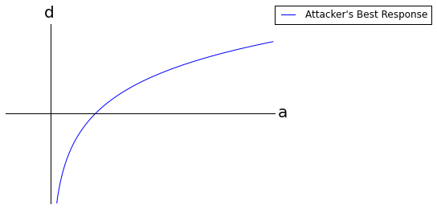

```python
from matplotlib import pyplot as plt
import numpy as np
%matplotlib inline
fig, ax = plt.subplots()
ax.plot(np.arange(.01, 5, .05), np.log(np.arange(.01, 5, .05)), label="Attacker\'s Best Response")
ax.spines['left'].set_position('zero')
ax.spines['right'].set_color('none')
ax.spines['bottom'].set_position('zero')
ax.spines['top'].set_color('none')
ax.spines['left']#.set_smart_bounds(True)
ax.spines['bottom']#.set_smart_bounds(True)
ax.xaxis.set_ticks_position('bottom')
ax.yaxis.set_ticks_position('left')
ax.set_xlim(-1,5)
ax.set_ylim(-2, 2)
ax.set_ylabel("a", rotation="horizontal", fontsize=20)
ax.yaxis.set_label_coords(1.03, .46)
ax.set_xlabel("d", fontsize=20)
ax.xaxis.set_label_coords(.16, 1.1)
ax.xaxis.set_ticks([])
ax.yaxis.set_ticks([])
ax.legend(loc=(1,1))
```

### The defender

Recall the defender's best response to any $a$ is $d^*$ such that $\frac{f(d^*)}{f(d^*-a)} = \frac{\pi c}{(1-\pi)X}$. Let's see what this looks like for various values of $a$.

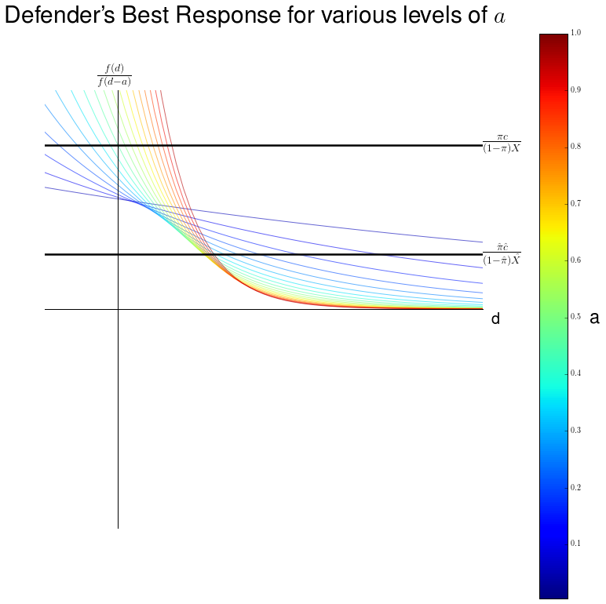

```python
from scipy.stats import norm
import matplotlib as mpl


from matplotlib import rc
rc('font',**{'family':'sans-serif','sans-serif':['Helvetica']})
## for Palatino and other serif fonts use:
#rc('font',**{'family':'serif','serif':['Palatino']})
rc('text', usetex=True)


fig, ax = plt.subplots(figsize=(10,10))
d = np.arange(-10, 10, .1)
for a in np.arange(.1, 2, .1):
    ax.plot(d, norm.pdf(d)/norm.pdf(d-a), color=plt.cm.jet(a / 2.), lw=1, alpha=0.6)
ax.spines['left'].set_position('zero')
ax.spines['right'].set_color('none')
ax.spines['bottom'].set_position('zero')
ax.spines['top'].set_color('none')
ax.spines['left']#.set_smart_bounds(True)
ax.spines['bottom']#.set_smart_bounds(True)
ax.xaxis.set_ticks_position('bottom')
ax.yaxis.set_ticks_position('left')
ax.set_xlim(-1,5)
ax.set_ylim(-2, 2)
ax.set_ylabel("d", rotation="horizontal", fontsize=20)
ax.yaxis.set_label_coords(1.03, .46)
ax.set_xlabel("$\\frac{f(d)}{f(d-a)}$", fontsize=20)
ax.xaxis.set_label_coords(.16, 1.06)
ax.xaxis.set_ticks([])
ax.yaxis.set_ticks([])
ax.legend(loc=(1,1))
ax.plot(np.arange(-10,10,1), 1.5*np.ones(len(np.arange(-10, 10,1))), color="black", linewidth=2.5)
ax.text(5,1.5, "$\\frac{\\pi c}{(1-\\pi)X}$", ha="left", va="center", fontsize=20)
ax.plot(np.arange(-10,10,1), .5*np.ones(len(np.arange(-10, 10,1))), color="black", linewidth=2.5)
ax.text(5,.5, "$\\frac{\\hat{\\pi} \\hat{c}}{(1-\\hat{\\pi})\\hat{X}}$", ha="left", va="center", fontsize=20)
ax2=fig.add_axes([1,0,.05,1])
ax2.set_xticks([])
cmap = mpl.cm.jet
norm = mpl.colors.Normalize(vmin=.005, vmax=1)
cb1 = mpl.colorbar.ColorbarBase(ax2, cmap=cmap,
                                norm=norm,
                                   orientation='vertical')
ax2.set_ylabel("a", rotation="horizontal", fontsize=24)
ax2.yaxis.set_label_coords(2, .51)
fig.suptitle("Defender\'s Best Response for various levels of $a$", fontsize=30, y=1.05)
```

In the figure above, I plot the defender's best response for various levels of $a$ and two different values of $\frac{\pi c}{(1-\pi)X}$. The defender's best response for a given $\frac{\pi c}{(1-\pi)X}$ and given $a$ is the $x$-coordinate where the downward sloping curve intersects the flat $\frac{\pi c}{(1-\pi)X}$ line. What is troublesome here as that the best response of $d$ as $a$ goes to zero depends on the value of $\frac{\pi c}{(1-\pi)X}$. If $\frac{\pi c}{(1-\pi)X}$ is "low enough" then as $a$ goes to $0$, the defender's best response goes to $\infty$. However, if $\frac{\pi c}{(1-\pi)X}$ "too high", then as $a$ goes to $0$, the defender's best response goes to $-\infty$.

Furthermore, since we know $f$ is log concave, we know that it only has one peak on the entire real line. Therfore, if $\frac{\pi c}{(1-\pi)X}<1$, then $d^*$ must be in the right tail. In other words, as $a$ goes to $0$, $\frac{f(d)}{f(d-a)}$ approaches 1 from below. Therefore, as $a$ goes to $0$ , $\frac{f(d)}{f(d-a)}>\frac{\pi c}{(1-\pi)X}$ Since $\frac{f(d)}{f(d-a)}$ is decreasing in $d$, the defender must raise $d$ so that $\frac{f(d)}{f(d-a)}=\frac{\pi c}{(1-\pi)X}$. This means that the defender's best response is *decreasing* in a.

Furthermore, if $\frac{\pi c}{(1-\pi)X}<1$, then as $a$ goes to $0$, the defender's best response *at least* goes to some constant (but might go to $\infty$). Therefore, since the defender's best response is decreasing in $a$ and the limit as $a$ goes to $0$ is *not* negative infinity *and* the attacker's best response is increasing in $d$, and does not have a minimum or maximum, the two best response functions must cross and therefore we have a unique Nash equilibrium (I can firm the "lines must cross" part up by using intermediate value theorem). This proves theorem 1 (below).

## Theorem 1:

If $\frac{\pi c}{(1-\pi)X}<1$, and $f$ has full support and is log concave on its support and at $\infty$ (see above for definition), the the game has a unique pure strategy Nash equilibrium.

# Generalizing (3/30)

```python
from matplotlib import rc
rc('font',**{'family':'sans-serif','sans-serif':['Helvetica']})
rc('text', usetex=True)
from matplotlib import pyplot as plt
import numpy as np
from scipy.stats import norm
%matplotlib inline
```

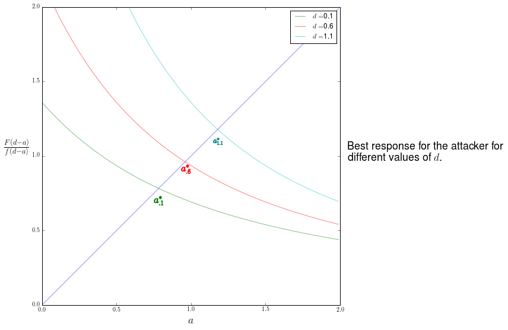

```python
a = np.arange(0,2,.01)
fortyfive = np.arange(0,2,.01)
fig, ax = plt.subplots()
ax.plot(fortyfive, fortyfive, alpha=.45)
for d in [.1,.6,1.1]:
    ratio = norm.cdf(d-a)/norm.pdf(d-a)
    ax.plot(a, ratio, label = "$d=$"+str(d), alpha=.5)
ax.set_xlabel("$a$", size=18)
ax.set_ylabel(r"$\frac{F(d-a)}{f(d-a)}$", size=18, rotation=0, ha="right" )
ax.legend()
ax.scatter(.782, .7, color="green", marker="$a_{.1}^*$", s=250)
ax.scatter(.963, .91, color="red", marker="$a_{.6}^*$", s=250)
ax.scatter(1.178, 1.1, color="teal", marker="$a_{1.1}^*$", s=250)
ax.set_xlim(0,2)
ax.set_ylim(0,2);
fig.set_figheight(9)
fig.set_figwidth(9)
fig.text(.92, .5, "Best response for the attacker for \n different values of $d$.", ha="left", size=18)
```

### But how do we generalize?

###### Kakutani/Brower?

- In order to apply Kakutani or Brower, the action space of the players needs to be compact (closed and bounded).
- In this case the action space is the entire real line.
- I attempted to put a restriction on the distribution such that I could prove the strategies outside of a closed interval were dominated and therefore the strategy space would be closed and bounded.
- Alas, no luck (yet).
- Furthermore, it would be difficult to prove that this result was unique

# Generalizing the SImple Cyber Scenario 3/30/15

In this section I will attempt to generalize the results to log concave probability distributions

### Recall:

To recap, the two necessary first order conditions are:

$a = \frac{F(d-a)}{f(d-a)}$

and

$\frac{f(d-a)}{f(d)} = \frac{B}{L}$

### Log Concave Probability

Direct from "Log-Concave Probability and Its Applications" by Mark Bagnoli, Ted Bergstrom

"Many interesting propositions in the economics of information are built on the assumption that the log of the cumulative distribution function of a random variable is a concave function. This property is equivalent to the ratio of the density function to the c.d.f. being a monotone decreasing function."

This might be relevant since the necessary condition for the attacker is the ratio of the c.d.f. to the density. Note that in this specific case, this condition is equivalent to $\frac{F(d-a)}{f(d-a)}$ monotone increasing in $d$ and monotone decreasing in $a$.

### The exponential distribution

Note that the exponential distribution is log-concave. With exponential noise, the defenders utility function (with a rate parameter of $1$) becomes

$$EU(d,a)_d = (1-\pi)X(1-e^{-d}) - c\pi(1-e^{-d}e^a)$$$$ = e^{-d}\big(\pi ce^a - (1-\pi)X\big) + (1-\pi)X - \pi c$$

Note that for any $a$, the defenders strategy will be to choose a threshold of $0$ (i.e. always sounding the alarm) or $\infty$, never sounding the alarm. More specifically, if $\pi ce^{a} >(1-\pi)X$ then the defender would set a threshold of 0. Otherwise, he would set a threshold of $\infty$. Therefore, the only pure strategy nash equilibria are the trivial ones in which the defender chooses a threshold of $0$ and the attacker chooses any level of attack such that $\pi ce^{a} >(1-\pi)X$.

**This means that log concavity is not sufficient to guarantee a non-trivial pure strategy equilibrium**

# Simple Cyber Scenario -- Iteration II - 2/20/14

### After the first dive into the simple model 4 follow-ups emerged

- There was a typo/algebra error
- Tie up corner solutions
- Try with an exponential distribution
- Possibly try solving with a power law distribution

## Fix typos and tie up corner solutions

Recall:

###### Claim : if $c\pi >X(1-\pi)$, then the defender sets the threshold to 1.

The expected utility of setting the threshold to 1 is given by: \begin{equation} EU(1)_d =(1-\pi)X - \pi c(1-a^2) \end{equation}

For $\delta \in (0,1)$, the expected utility of setting the threshold to $1-\delta$ is given by

\begin{equation} EU_d(1-\delta) = (1-\pi)X(1-\delta^2)- \pi c (1-2\delta a -a^2 - \delta^2) \end{equation}

Then, the change in utility from changing the threshold from $1$ to $1-\delta$ is given by \begin{align} EU(1)- EU(1-\delta) &= (1-\pi)X\delta^2 - \pi c \delta^2 - \pi c 2\delta a\ &=((1-\pi)X - \pi c)\delta^2 - \pi c 2 \delta a \end{align}

Note that if $c\pi >X(1-\pi)$, the change in utility from lowering the threshold is unambiguously negative. Therefore if $c\pi >X(1-\pi)$, the defender sets the threshold to 1.

### Best Responses

The attacker's best response (by using the quadratic formula) is given by:

\begin{equation} BR_A(d) = \frac{1}{3} \big( 2 (d-1) + \sqrt{d^2-2d+4}\big) \end{equation}

The best response for the defender is given by (same as before)

\begin{equation} BR_d(a) = 1 + \frac{ac\pi}{c\pi +x(\pi-1)}\ \end{equation}

Doing a ton of tedious algebra, if we let $B = \frac{c \pi}{c\pi - (\pi-1)X}<0$, then the attackers equilibrium strategy, $a^*$ is given by \begin{equation} a^ *= \frac{1}{\sqrt{3-4B+B^2}} \end{equation} and therefore the defender's best response is given by \begin{equation} d^* = 1 + \frac{B}{\sqrt{3-4B+B^2}} \end{equation}

Doing more algebra, we know that: \begin{align} \frac{\partial{B}}{\partial{X}} &> 0 \ \frac{\partial{B}}{\partial{\pi}} &< 0 \ \frac{\partial{B}}{\partial{c}} &< 0 \ &\text { and }\ \frac{d a^*}{dB} = (2-B)(3-4B+B^2)^{-3/2}& > 0 \ \end{align}

This implies

\begin{align} \frac{\partial{a^*}}{\partial{X}} &> 0 \\ \frac{\partial{a^*}}{\partial{\pi}} &< 0 \\ \frac{\partial{a^*}}{\partial{c}} &< 0 \\ \end{align}

This proves the intuitive result that if the defenders reward for not sounding an alarm increases, the amount of attack will increase. It also shows as the exogenous probability of attacker increases, the amount of attack decreases. Finally as the cost of an attack to the defender increases, the attacker will attack less.

For the defender we have \begin{equation} \frac{d d^*}{dB} = \frac{3-2B}{3-4B+B^2} > 0 \end{equation}

This implies:

\begin{align} \frac{\partial{d^*}}{\partial{X}} &> 0 \\ \frac{\partial{d^*}}{\partial{\pi}} &< 0 \\ \frac{\partial{d^*}}{\partial{c}} &< 0 \\ \end{align}

In words, the more reward a defender receives for not sounding a false alarm, the higher the threshold. The more likely an attacker, the lower the threshold. Finally, a higher cost to attack indicates a lower threshold.

### Closed form solutions with other distributions

- (I am omitting the algenra here and just stating the result) When using the exponential distribution, the equilibrium has the two players mixing. Furthermore, I could not find a closed form solution for the attacker's strategy. It boils down to an equation of the firm $e^x +x =c$, which I don't believe is solvable.

### Power law

This is the start of a rework of the same example with a power law distribution : $F(\epsilon) = 1-\frac{1}{\epsilon}$ and $f(\epsilon) = \frac{1}{\epsilon^2}$ We will also assume that $c\pi< (1-\pi)X$. Otherwise, the defender would never sound the alarm (the argument is similar as above, I think).

The FOC for the attacker is given by: \begin{equation} 1 - \frac{1}{d - a} - \frac{a}{(d - a)^2} = 0 \end{equation}

The second order condition to ensure a maximum is then given by \begin{equation} SOC = \frac{a}{a-d}-1 <0 \end{equation}

The attacker's best response is given by \begin{align} BR_A(d) = d + \sqrt{d} \ \text{ and } \ BR_A(d)= d - \sqrt{d} \end{align}

However, we can rule out the attacker setting an attack level higher than the defender's threshold so the best response for the attacker is $d-\sqrt{d}$. This implies that the SOC is \begin{equation} SOC = \frac{d-\sqrt{d}}{d-\sqrt{d} -d} -1 = \frac{d - \sqrt{d}}{-\sqrt{d}} -1 <0 \end{equation}

For the defender, the FOC is given by \begin{align} 0 &= (1-\pi)Xf(d) - \pi c f(d-a)\ & = (1-\pi)X\frac{1}{d^2} - \pi c(\frac{1}{(d-a)^2}) \end{align}

If we let $Z = (1-\pi)X>0$ then this simplifies to \begin{equation} d^2(Z-\pi c) - 2Zad +Za^2=0 \end{equation}

Solving for the best response function yields \begin{align} BR*{D1}(a) = \frac{a}{1-\sqrt{\frac{c \pi}{Z}}} \ \text {and } \ BR*{D2}(a) = \frac{a}{1+\sqrt{\frac{c \pi}{Z}}} \end{align}

Now it gets a bit tricky (i.e. I have to delve into my memory of calc 1). The attacker's best response is $BR_A(d) = d- \sqrt{d}$ Plug this into the best response functions and solve:

\begin{align} d = \frac{d-\sqrt{d}}{1-\sqrt{\frac{c \pi}{Z}}} \implies d \sqrt{\frac{c\pi}{Z}} - \sqrt{d} =0 \\ \text {and } \\ d = \frac{d-\sqrt{d}}{1+\sqrt{\frac{c \pi}{Z}}}\implies d \sqrt{\frac{c\pi}{Z}} + \sqrt{d} =0 \end{align}

However, since we are assuming positive parameters, the second equation is impossible. Therefore, we solve the first and see that: \begin{equation} d^ *= \frac{Z}{c\pi} = \frac{(1-\pi)X}{c\pi} \end{equation} and therefore \begin{equation} a^*= \frac{(1-\pi)X}{c\pi} - \sqrt{\frac{(1-\pi)X}{c\pi}} \end{equation}

For the defender, it is simple to see that as the reward for not sounding an alarm increases ($X$), the threshold increases. As the cost of an intruder increases ($c$), the threshold decreases. With a tad bit of calculus and algebra, we can see that as the exogenous probability of an attacker increases ($\pi$), the threshold decreases.

The attacker is a bit trickier but we can write

\begin{align} & \frac{\partial{a^*}}{\partial{X}} = (1-\frac{1}{2d^{1/2}})\frac{\partial{d^*}}{\partial{X}} >0 \text{ (because } d^*>1\text{)}\\ & \frac{\partial{a^*}}{\partial{c}} = (1-\frac{1}{2d^{1/2}})\frac{\partial{d^*}}{\partial{c}} <0 \\ & \frac{\partial{a^*}}{\partial{\pi}} = (1-\frac{1}{2d^{1/2}})\frac{\partial{d^*}}{\partial{\pi}} <0 \end{align}

Again, we get the same summary as before when we used the triangle distribution

## Summary

In this week's works I :

- (Hopefully) fixed algebraic errors.
- Completely characterized the solutions and dealt with corner cases when the noise follows a triangle distribution.
- Repeated the same experiment but this time with a power-law distribution and obtained the same results.

Basically, this confirms that under some noise distributions, the attacker and defender do not need to randomize their strategies in order to be strategic. Instead, the attacker chooses the amount of attack such that he optimally trades off going undetected by the sensor vs accumulating utility.

In both cases, the attacker chooses less than the maximum amount of attack. This is important because most of the practical cyber security literature assumes that once an attacker infiltrates a network, they accumulate as much utility as possible without considering the probability of getting caught. However, the results in both of these models show that a rational attacker will take into account the anomaly detection system (defender's threshold) when choosing how much to attack.

Moving forwards, I think it would be best to "play" with these results a bit more. I would like to develop the results when the variance increases and I hope I can do it with these two distributions. After that, I would like to put the work into the context of the literature and current cyber security.

Finally, the question that keeps popping up in my mind is where this work will fit in my dissertation. I see two possibilities. The first (and the one I am going to shoot for), is that I can work and extend this model (in closed form, of course) that it becomes a stand alone paper. Then my dissertation would have this paper serving as an "economics" style game theoretic model and still continue with the large-network, CS style game theoretic model.

The second option (and the one I am trying to avoid) is that this work is just a motivator for other work and does not stand alone.

Do you have any thoughts or opinions?

# Simple Cyber Scenario -- Iteration II - 2/9/14

Here I make a *slight* modification to your scenario (it makes it simpler!!!!) and work through an entire example, fleshing out the "hand waving".

## Comment summary

- Simple means **simple**
- Work even closer to an analytical result
- Strip away everything that is not necessary (including dynamics)
- Look into continuous functions/variables (might be easier to work with)

## Recap of main points

- Attacker chooses intrusion level ; more is better
- Defender chooses defense threshold, trading off false alarm vs potential intrusion
- Defender does not know if there is any intrusion
- Attacker does not observe the sensor
- Result 1 : The attacker chooses the less than maximum amount of intrusion
- Result 2 : Randomization is not necessary due to the noise

## Notation

- $\pi$ : Probability of an intruder
- $a$, attacker's level of intrusion
- $d$, defender's level of detection
- $s = a + \epsilon$ is the reading of the sensor
  - If no attacker is present, $a=0$
  - $\epsilon \sim F(\epsilon)$
- If $s>d$, the alarm is tripped
- Attacker receives a utility of $a$ if the alarm is not tripped
- The defender earns a utility of $X$ if he does not sound the alarm when an attacker is not present
- (The only difference) The defender incurs a constant cost of $c$ if the network does not shut down if the attacker is present. Note that the cost does not depend on the amount of attack (it makes the math simpler).

## Solving it

Here I basically solve for the same results you did, but do it in my "own words."

### The expected utility of the defender

The first term on the RHS is the utility the defender earns by not sounding the alarm if an attacker is present. The second term on the RHS is the utility the defender earns if the attacker is present and the defender does not sound the alarm. Since the defender earns a utility of $0$ whenever he does sound the alarm, those terms are omitted.

We can rewrite this using the notation of the CDF as:

$EU_d = (1-\pi)F(d)X - \pi F(d-a)c$

If we define $B$ (as in benefit of not having a false alarm) as $(1-\pi)X$ and $L$ (as in loss of not sounding an alarm when the attacker is present) as $\pi c$, then we have:

$EU_d = BF(d) - LF(d-a)$ ( Same as prof L's, first equation)

Taking derivatives to get the FOC's and then rearranging we see that

$\frac{f(d-a)}{f(d)} = \frac{B}{L}$

Interestingly, this shows that the defender's optimal decision is to set $d$ in order to determine the optimal likelihood ratio! Interestingly, this is **not** how cyber security works. In fact current attack detectors simply look at F(d) and set a threshold for that quantity. However, this provides an analytical background as to **why** a likelihood ratio detector would be superior to a simple anomaly detector.

Now, the attacker's expected utility is simply:

$EU_a = P(\text{ no alarm })a = F(d-a)a$

SImple enough to see, increasing $a$ increases his reward if he does not get caught but also increases his probability of getting caught. The first order condition is

$F(d-a) - af(d-a) = 0$

Rearranging, we get:

$a = \frac{F(d-a)}{f(d-a)}$

To recap, the two necessary conditions we have are:

$a = \frac{F(d-a)}{f(d-a)}$

and

$\frac{f(d-a)}{f(d)} = \frac{B}{L}$

### Closed Form (writing out the hand waving)

Using your suggestion, we will let $f(\epsilon) = 2-2\epsilon$ for $\epsilon \in [0,1]$

Omitting the algebra. the best response for the defender is given by

\begin{equation} BR_d(a) = 1 + \frac{ac\pi}{c\pi +x(\pi-1)}\ \end{equation}

For the attacker, we can factor his first order condition as

\begin{equation} (a-d+1)(2a-d)=0 \end{equation}

This implies that \begin{equation} BR_a(d) = \frac{d}{2} \end{equation}.

Since we want to impose the realistic restriction that if the defender **knows** an attacker is present, he will sound the alarm, we need to put some restrictions on the parameters. If the output of the sensor is $>1$, the maximum of the noise, then the defender knows that the attacker must be present in the network. Therefore, we restrict the analysis to where the defender's strategy $<=1$. This implies that $c\pi +x(\pi-1)<0$, or in other words, $x>\frac{c \pi}{1-\pi}$

This also suggests we can ignore the case of $a = d-1$. This is because the defender will never set a threshold higher than 1 (because the noise is bounded by 1, so anything above 1 must be due to the presence of an attacker). Therefore, $d-1$ will always be $\leq 0$, which is not in the attacker's strategy space.

We can now solve for the optimal defender's threshold as

\begin{equation} d^* = 1 + \frac{c\pi}{\frac{1}{2}c\pi + \pi x -x} \end{equation}

Now to do some comparative statics:

- An increase in the reward to not sounding a false alarm (i.e. derivative of $d^* \; \;w.r.t. X$):

\begin{equation} d' = \frac{ - c\pi (\pi-1)}{(\frac{1}{2}c\pi + \pi x -x)^2} \end{equation}

In this case, the denominator is positive and the numerator is also positive (since $\pi<1$). This means that as the reward for not sounding a false alarm goes up, the defender is raises his threshold, which in turn induces more attacks.

- An increase in the cost of not catching an attacker, (i.e. derivative of $d^* \; \;w.r.t. c$):

\begin{equation} d' = \frac{(\frac{1}{2}c\pi + \pi x -x)\pi - c\pi\frac{1}{2}\pi}{(\frac{1}{2}c\pi + \pi x -x)^2} \end{equation}

The first term in the numerator is negative (because we are only considering the equilibria in (0,1) ) and the second term is positive and therefore the entire derivative is negative. This implies that, as expected, as the cost of an intruder increases, the defender lowers his threshold.

- An increase in the cost of not catching an attacker, (i.e. derivative of $d^* \; \;w.r.t. \pi$):

\begin{equation} d' = \frac{(\frac{1}{2}c\pi + \pi x -x)c - (c\pi\frac{1}{2}c + x)}{(\frac{1}{2}c\pi + \pi x -x)^2} \end{equation}

Again, the first term in the numerator is negative and the second term is positive, implying that as the exogenous probability of the attacker being in the network increases, the defender lowers his threshold and the attackers then lower the amount of attack they choose.

### Graphically:

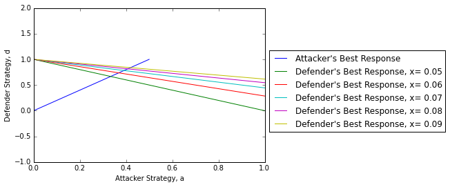

```python
from matplotlib import pyplot as plt
%matplotlib inline
import numpy as np
fig, ax = plt.subplots()
ax.set_xlabel('Attacker Strategy, a')
ax.set_ylabel('Defender Strategy, d')
ax.plot(strat_space/2., strat_space, label = 'Attacker\'s Best Response')
for i in np.arange(.05, .1, .01):
    pi=.2
    x=i
    c=.1
    strat_space = np.arange(0,1.001,.001)
    br = 1 + (strat_space*c*pi)/(c*pi +x*(pi-1))
    ax.plot(strat_space, br, label='Defender\'s Best Response, x= ' + str(i))
#ax.plot(strat_space, np.ones(len(strat_space)))
    ax.set_ylim(-1,2)
plt.legend(loc=1, ncol=1, bbox_to_anchor= (1.8,.75))
```

## Summary

- I established basic intuitive results for a cyber scenario that is novel. More specifically I showed that in the presence of noise, attackers and defenders do not necessarily need to mix to out-wit their opponent. Instead, they choose their parameters in order to either hide in the noise (for the attacker) and discern a signal from noise (for the defender). This suggests that attack-detection games in the cyber realm are different from the typical matching-pennies set-up they are typically modeled as.
- The most difficult aspect for me was to deal with the a noise term that is bounded. I think I can elaborate more on this model and present the (counter-intuitive) result that there are certain scenarios where the defender would want to set his threshold higher than the upper bound of the noise. I can think of multiple ways around this (a priori parameter restrictions, slightly different utility functions, another clever noise distribution, maybe a few other methods) but it would take some time to pound out the details. Furthermore, I wanted to have a full closed form solution (for practice). However, it is likely that I could have came across the same intuition assuming a normal distribution on the noise. I wouldn't have a fully specified closed form but would be able to gather the same intuition ( I tried with exponential noise and that was pretty hard to work with. Same with power law).
- I see a number of possible next steps, though I am not sure which one to follow:
  - 1) Keep working with this model and work out the "kinks" (weird, non-intuitive solutions)
  - 2) Establish more general results (i.e. keeping the noise function more general and determine which properties of the noise are necessary to maintain the intuitive results.
  - 3) Continue with the closed-form model and see what happens (to expected utilities/strategies) when the noise becomes more pronounced. I can do this by changing the bounds on the triangle distributions.
  - 4) Expand this model to a network scenario where the attacker possibly chooses among many targets.

Actually 1-4 might be a logical progression of how I should proceed, but I wanted to check with you first for some feedback.

# Justin's Scratch Work

```python
sqterm =.5
x=np.arange(1,10,.01)
y1 = x/(1+sqterm**.5)
y2=x/(1-sqterm**.5)
```

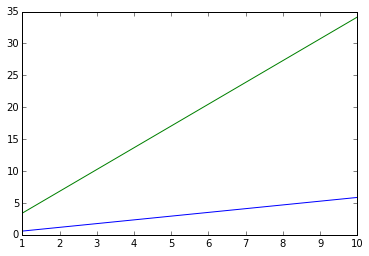

```python
plt.plot(x, y1)
plt.plot(x, y2)
```

## The old way

Using your suggestion, we will let $f(\epsilon) = 2-2\epsilon$ for $\epsilon \in [0,1]$

Omitting the algebra. the best response for the defender is given by

\begin{equation} BR_d(a) = 1 + \frac{a\pi(a-x)}{a\pi-x}\ \end{equation}

For the attacker, we can factor his first order condition as

\begin{equation} (a-d+1)(2a-d)=0 \end{equation}

This implies that \begin{equation} BR_a(d) = \frac{d}{2} \end{equation}.

(We can ignore the case of $a = d-1$. This is because the defender will never set a threshold higher than 1 (because the noise is bounded by 1, so anything above 1 must be due to the presence of an attacker). Therefore, $d-1$ will always be $\leq 0$, which is not in the attacker's strategy space.

This establishes that $a(d)$ is strictly increasing in $d$. A simple and expected result.

However, actually deriving equilibrium strategies is not straightforward. First we have to make a few more technical assumptions:

- $a \neq \frac{x}{\pi}$ (or else the defender's best response would not be defined
- $x < 1$. If this wasn't the case, the defender would have an incentive to not sound the alarm, knowing an attacker is present.

### Some Issues

Incentive for defender to set strategy$>1$.

The reason is that given an attacker's strategy under some parameter configurations, the defender might want to set his strategy such that he does not sound an alarm, even if he knows an attacker is present. For example, given an attacker's strategy, the second term in the expected utility for the defender *increases* in $d$ if $d-a<1$. Of course, this can occur even if $d$ is already $>1$.

This is problematic because it implies we cannot restrict the defender's strategy to be less than the maximum value of the noise, a reasonable assumption...

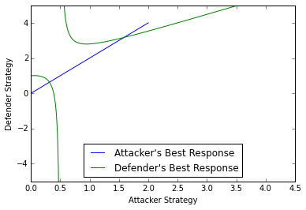

```python
from matplotlib import pyplot as plt
%matplotlib inline
import numpy as np
pi=.2
x=.1
strat_space = np.arange(0,4.001,.001)
fig, ax = plt.subplots()
ax.set_xlabel('Attacker Strategy')
ax.set_ylabel('Defender Strategy')
br = 1 + (strat_space*pi*(strat_space-x))/(strat_space*pi-x)
ax.plot(strat_space/2., strat_space, label = 'Attacker\'s Best Response')
ax.plot(strat_space, br, label='Defender\'s Best Response')
#ax.plot(strat_space, np.ones(len(strat_space)))
ax.set_ylim(-5, 5)
plt.legend(loc=8)
```

```python
def defendereu(pi,x,d ,c,a):
    if d<= 0:
        Fd=0
    elif d>=1:
        Fd=1
    else:
        Fd = 2*d-d**2
    if d-a <=0:
        Fda = 0
    elif d-a >=1:
        Fda=1
    else:
        Fda = 2*(d-a)-(d-a)**2
    eu = (1-pi)*Fd*x + pi*Fda*c
    return eu

defendereu(.2, .1, 10, 1.5, .2)
```

```
0.38000000000000006
```

```python
import numpy as np
def EU_defender_exponential(d, a=200, X=1, C=.3, pi=.5):
    return (1-pi)*X *(1-np.exp(-(d))) - pi*C*(1-np.exp(-(d-a)))
```

```python
eus = []
for d in np.arange(0,3,.01):
    eus.append(EU_defender_exponential(d))
```

```python
from matplotlib import pyplot as plt
%matplotlib inline
```

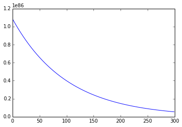

```python
plt.plot(eus)
```

```python
def attacker_eu_power(a, d=9, X=1, C=.3, pi=.5):
    return a*(1-1./float(d-a))

eus = []
for a in np.arange(1,8.9,.01):
    eus.append(attacker_eu_power(a))
```

```
(0, 6)
```

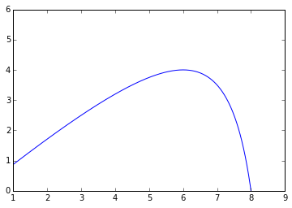

```python
plt.plot(np.arange(1,8.9,.01), eus)
plt.ylim(0,6)
```

```python
def defender_eu_power(d,a=2, X=10, C=2, pi=.5):
    return (1-pi)*X*1./d**2 - pi*c*1/np.float_(d-a)**2

dstrat = np.arange(3,10,.01)
deu = defender_eu_power(dstrat)
```

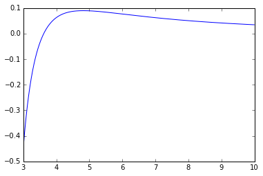

```python
plt.plot(dstrat, deu)
```

However, recall that \begin{align} EU_A(a) &= aF(d-a) \ &=a(1-\frac{1}{d-a})\ &\text{Therefore} \ EU_A(d + \sqrt{d}) &= d+\sqrt{d} - \frac{d+\sqrt{d}}{d-(d+\sqrt{d})} \ & = d+\sqrt{d} - \frac{d+\sqrt{d}}{-\sqrt{d}} \ & = d+\sqrt{d} + \frac{d+\sqrt{d}}{\sqrt{d}} \ & = (\sqrt{d}+1)^2 \end{align}

Similarly, \begin{equation} EU_A(d + \sqrt{d}) =(\sqrt{d}-1)^2 \end{equation}

```python
def plot_attacker_br(d):
    return d - d**.5

def plot_defender_br1(a, c, pi, X):
    Z= (1-pi)*X
    return a/(1-(c*pi/Z)**.5)

def plot_defender_br2(a,c, pi, X):
    Z= (1-pi)*X
    return a/(1+(c*pi/Z)**.5)

c=2
pi=.5
X=10

strats = np.arange(1,10,.01)
abr = plot_attacker_br(strats)
dbr1 = plot_defender_br1(strats, c,pi,X)
dbr2 = plot_defender_br2(strats, c,pi,X)
```

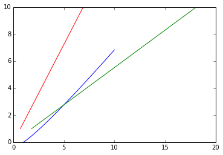

```python
plt.plot(strats, abr)
plt.plot(dbr1, strats)
plt.plot(dbr2, strats)
```

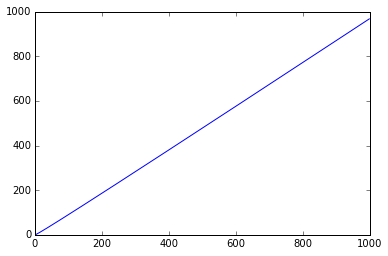

```python
plt.plot(np.arange(1000) - np.arange(1000)**.5)
```

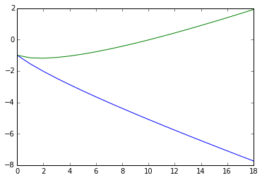

```python
x= np.arange(1,20,1)
d1 = (x -x**.5)/(1+.3) -x
d2 = (x -x**.5)/(1-.3) -x
plt.plot(d1)
plt.plot(d2)
```

```python
from matplotlib import pyplot as plt
import numpy as np
%matplotlib inline

def eu(d, a=.25, oneminuspix=.5, pic=.75):
    return oneminuspix*(2*d - d*d) - pic*(2*(d-1) - (d-a)**2)
```

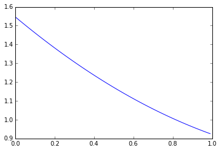

```python
plt.plot(np.arange(0,1,.01), (eu(np.arange(0,1,.01))))
```

```python
eu(.5) - eu(.4)
```

```
-0.06499999999999995
```

**Lemma 1:** Log concavity implies that if $f'(x) =0$, then for any $x' \neq x$, $f'(x) \neq 0$

**Lemma 2:** There exists an $x^*$ such that $f'(x^*)=0$